# Tutorial 2

Andrew Chou

29 August 2021

## Question 1: Logarithmic Spirals

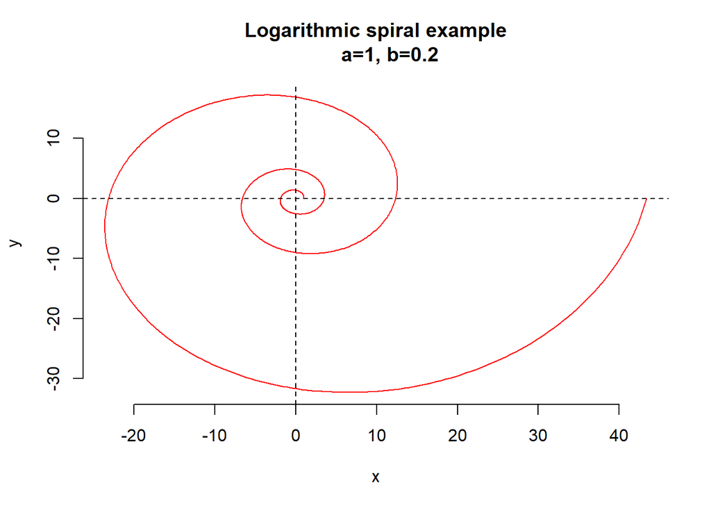

```r
theta <- seq(from = 0, to = 6 * pi, length.out = 1000)
r <- exp(0.2 * theta)
x <- r * cos(theta)
y <- r * sin(theta)
plot(x, y, type = 'l', col = 'red',
     bty = 'n', xlab = 'x', ylab = 'y',
     main = 'Logarithmic spiral example
     a=1, b=0.2')
abline(v = 0, lty = 'dashed')
abline(h = 0, lty = 'dashed')
```

## Question 2: Debugging Functions

### two_step_v1 mistakes

- line 2: condition can be simpliflied to !(h_name %in% colnames(h_dists))
- line 3: break should be replaced with a return statement, like return(“Input is incorrect.”) as break is for exiting loops, not functions.
- line 6, 7, 8: typos. h_dist should be h_dists.
- line 7: use <- instead of = to assign.

### two_step_v2 mistakes

- line 2: converts everything to NA.
- line 4: no need to match, can just use indexing.
- line 10: use return instead of print.

## Question 3: Wine types

### read wine_titles.rds

```r
wine_data <- readRDS("../data/wine_titles.rds")
```

### cleaning

1. find absence of @ symbol in taster_twitter_handle column using regex, then reassign their correct values.

```r
library(stringr)
misplaced_ids <- which(str_detect(
  wine_data$taster_twitter_handle,  "^@", negate = TRUE))

wine_data[misplaced_ids,]
```

```
##                   taster_name taster_twitter_handle            title
## 382                      <NA>        Joe Czerwinski           @JoeCz
## 1365                     <NA>     Michael Schachner      @wineschach
## 9070                     <NA>            Roger Voss       @vossroger
## 11686       Willamette Valley          Paul Gregutt      @paulgwine
## 12293        California Other            Jim Gordon @gordone_cellars
## 23243                    <NA>         Lauren Buzzeo        @laurbuzz
## 30621             Long Island        Joe Czerwinski           @JoeCz
## 45271                    <NA>       Susan Kostrzewa    @suskostrzewa
## 49429         Columbia Valley          Paul Gregutt      @paulgwine
## 55717                    <NA>      Anne Krebiehl MW      @AnneInVino
## 67412 Walla Walla Valley (WA)       Columbia Valley     Paul Gregutt
## 78751            Finger Lakes         Lauren Buzzeo        @laurbuzz
```

```r
for (i in misplaced_ids) {
  temp <- wine_data[i,1]
  wine_data[i,1] <- wine_data[i,2]
  wine_data[i,2] <- wine_data[i,3]
  wine_data[i,3] <- temp
}

wine_data[misplaced_ids,]
```

```
##             taster_name taster_twitter_handle                   title
## 382      Joe Czerwinski                @JoeCz                    <NA>
## 1365  Michael Schachner           @wineschach                    <NA>
## 9070         Roger Voss            @vossroger                    <NA>
## 11686      Paul Gregutt           @paulgwine        Willamette Valley
## 12293        Jim Gordon      @gordone_cellars        California Other
## 23243     Lauren Buzzeo             @laurbuzz                    <NA>
## 30621    Joe Czerwinski                @JoeCz             Long Island
## 45271   Susan Kostrzewa         @suskostrzewa                    <NA>
## 49429      Paul Gregutt           @paulgwine          Columbia Valley
## 55717  Anne Krebiehl MW           @AnneInVino                    <NA>
## 67412   Columbia Valley          Paul Gregutt Walla Walla Valley (WA)
## 78751     Lauren Buzzeo             @laurbuzz            Finger Lakes
```

2. row 67412 is still wrong. We can get Paul Gregutt’s twitter handle from other rows, but we’re not sure whether the title is Columbia Valley or Walla Walla Valley (WA). Let’s keep the latter one.

```r
wine_data[67412, 1] <- "Paul Gregutt"
wine_data[67412, 2] <- "@paulgwine"

wine_data[67412,]
```

```
##        taster_name taster_twitter_handle                   title
## 67412 Paul Gregutt            @paulgwine Walla Walla Valley (WA)
```

### extract regions

1. using regex to extract the text from the first open bracket to the last close bracket, then remove both brackets.

```r
regions <- str_extract(wine_data$title,  "\\(([^)]+)\\)+")
rm_brackets <- function(str) {
  return(substring(str, 2, nchar(str) - 1))
}

regions <- sapply(regions, rm_brackets)
regions <- unname(regions)
head(regions)
```

```
## [1] "Etna"                "Douro"               "Willamette Valley"
## [4] "Lake Michigan Shore" "Willamette Valley"   "Navarra"
```

2. Check that there is no title with two brackets that is not nested and add column to dataframe

```r
bad <- which(str_detect(regions,  "[)].*[(]"))
bad
```

```
## integer(0)
```

```r
wine_data$region <- regions
head(wine_data)
```

```
##          taster_name taster_twitter_handle
## 1      Kerin O’Keefe          @kerinokeefe
## 2         Roger Voss            @vossroger
## 3       Paul Gregutt           @paulgwine
## 4 Alexander Peartree                  <NA>
## 5       Paul Gregutt           @paulgwine
## 6  Michael Schachner           @wineschach
##                                                                                 title
## 1                                                   Nicosia 2013 Vulkà Bianco  (Etna)
## 2                                       Quinta dos Avidagos 2011 Avidagos Red (Douro)
## 3                                       Rainstorm 2013 Pinot Gris (Willamette Valley)
## 4                 St. Julian 2013 Reserve Late Harvest Riesling (Lake Michigan Shore)
## 5 Sweet Cheeks 2012 Vintner's Reserve Wild Child Block Pinot Noir (Willamette Valley)
## 6                               Tandem 2011 Ars In Vitro Tempranillo-Merlot (Navarra)
##                region
## 1                Etna
## 2               Douro
## 3   Willamette Valley
## 4 Lake Michigan Shore
## 5   Willamette Valley
## 6             Navarra
```

### ideas to extract vintage year

1. First, we can extract all four-digit numbers in each title.
2. Then, we can remove numbers higher than the current year.
3. If we have data of each winery’s established year, we can also remove numbers less than its corresponding winery’s established year.
4. The highest of the remaining numbers is probably the vintage year.